# Aula 11 - Introdução à Econometria

Autor

João Ricardo F. de Lima

Data de Publicação

27 de outubro de 2025

# Modelos de Escolha Discreta

## Introdução

Também conhecidos como modelos de microeconometria. Analisam escolhas individuais:

1. voto
2. consumo
3. preferencias
4. adotar ou não uma tecnologia, etc;

Modelos usados quando a variável dependente não mede quantitativamente um resultado econômico, mas indica se um ou mais resultados ocorreram, ou não. Assim, estes modelos são diferentes dos vistos anteriormente. Os modelos de escolha vão modelar probabilidades e a econometria será usada para fazer afirmações sobre a probabilidade de eventos ocorrerem.

$$P(y=1|x)=P(y=1|x_1,x_2, \dots, x_k)
\tag{1}$$

Existem vários modelos desta família:

**Escolha Binária**: O individuo se depara com um par de alternativas e escolhe entre as duas aquela que lhe traz maior grau de utilidade;

**Escolha Multinomial**: O individuo se depara com mais de duas alternativas e escolhe uma que lhe traz maior grau de utilidade;

**Escolha Ordenada**: O individuo expressa a força de suas preferencias com relação a um resultado particular. As possibilidades estão ordenadas de forma a indicar a força das preferencias.

## Modelos Logit e Probit Binários

Para estudar comportamento individual, são construídos modelos que relacionem a decisão tomada com um conjunto de covariadas, como no MCRL. Cada uma será analisada no contexto dos modelos de probabilidade:

$$Prob(y=1|x)=G(\beta_0+\beta_1x_1+\dots+\beta_kx_k)=G(x\beta)
\tag{2}$$

sendo $Prob(y=1|x)$ a probabilidade de sucesso dado um conjunto de variáveis independentes; $G$ uma função de distribuição de probabilidade acumulada $0<G(z)<1$.

Várias funções não lineares têm sido sugeridas para a função $G$ de forma a se garantir que as probabilidades previstas estejam entre 0 e 1. As duas mais importantes são: Logística e a Normal.

No modelo **Logit**, a função logística é:

$$G(z)=\Lambda(z)\frac{exp(z)}{1+exp(z)}
\tag{3}$$

que está entre zero e um para todos os números z reais. Esta é a função de distribuição acumulada de uma variável aleatória logística padrão.

No modelo **Probit**, $G$ é a a função de distribuição de probabilidade acumulada Normal, expressa pela integral:

$$G(z)=\Phi(z)=\int_{-\infty}^{z} \phi(v)dv
\tag{4}$$

em que $\phi(z)$ é a densidade normal padrão.

$$\phi(z)=(2\pi)^{-1/2}exp(-Z^2/2)
\tag{5}$$

A escolha de $G$ mais uma vez assegura que (2) esteja entre 0 e 1 para todos os valores dos parâmetros e $x_j$.

## Modelos de Regressão Latente

Considere uma tomada de decisão de compra de um bem. A compra ocorre se o beneficio marginal for maior que o custo marginal da aquisição. É possível modelar a diferença entre benefício e custo como uma variável não observável/latente $y^*$ tal que $y^*=\mathbf{x'\beta}+\varepsilon$.

Considere que $\varepsilon$ tem média zero e pode ter uma distribuição logística com variância $\pi^2/3$ ou normal padrão com variância 1. $y^*$ não é observado, mas se sabe se a compra foi feita ou não. Então, observa-se:

$$y=1 \quad se \quad y^*>y^L$$

$$y=0 \quad se \quad y^* \leq y^L$$

$y^L$ é denominado de valor limite ou **threshold**. Considerando $y^L=0$ como valor de referência:

$$P(y=1|x)=P(y^*>0|x)=P(\mathbf{x'\beta}+\varepsilon>0)$$

$$=P(\mathbf{\varepsilon>-x'\beta})=P(\mathbf{\varepsilon<x'\beta})=\mathbf{G(x'\beta)}
\tag{6}$$

com G(z) sendo a função de distribuição de probabilidade acumulada da variável aleatória, $\varepsilon$.

## Efeitos Marginais

Independente do modelo escolhido é importante observar que os parâmetros do modelo, que não é linear, não são necessariamente os efeitos marginais, como ocorre no caso do MCRL. No caso do Modelo Probit, o efeito marginal das variáveis contínuas é dado por:

$$\frac{\partial P(y=1|x)}{\partial x_j}=\phi(\mathbf{x'\beta})\beta_j
\tag{7}$$

com o $\phi$ sendo a função de distribuição de probabilidade Normal.

Assim, se busca explicar como a probabilidade de que $y=1$ muda se a variável explicativa $x_j$ mudar em uma unidade.

No caso do Modelo Logit, o efeito marginal das variáveis contínuas é dado por:

$$\frac{\partial P(y=1|x)}{\partial x_j}=\lambda(\mathbf{x'\beta})[1-(\mathbf{x'\beta})]\beta_j
\tag{8}$$

com o $\lambda$ sendo a função de distribuição de probabilidade logística. No caso da variável explicativa ser uma dummy, o efeito marginal é dado por

$$P(y=1|x, d=1)-P(y=1|x, d=0)
\tag{9}$$

ou, em outras palavras,

$$G(\beta_0+\beta_1+\dots+\beta_kx_k-G(\beta_0+\dots+\beta_kx_k)
\tag{10}$$

Assim, por exemplo, se o y for uma variável relativa a adoção ou não de uma tecnologia agropecuária e x for uma variável *dummy* ter recebido assistência técnica e gerencial (ATeG) em sua propriedade ou não ter, então, a equação dada em (10) será a mudança na probabilidade de adotar a tecnologia em razão de ter recebido ATeG. Vale ressaltar que apenas o conhecimento do sinal do $\beta_1$ é suficiente para determinar se ter recebido ATeG teve efeito positivo ou negativo na adoção. Contudo, para encontrar a magnitude do efeito, tem-se que estimar a quantidade em (10).

Considere o modelo abaixo:

$$P(y=1|z)=G(\beta_0+\beta_1z_1+\beta_2z_1^2+\beta_3log(z_2)+\beta_4z_3)
\tag{11}$$

Os efeitos marginais são:

$$\frac{\partial P(y=1|z)}{\partial z_1}=g(\mathbf{x'\beta})(\beta_1+2\beta_2z_1)
\tag{12}$$

$$\frac{\partial P(y=1|z)}{\partial z_2}=g(\mathbf{x'\beta})(\frac{\beta_3}{z_2})
\tag{13}$$

$$\frac{\partial P(y=1|z)}{\partial z_3}=g(\mathbf{x'\beta})(\beta_4)
\tag{14}$$

## Estimação por Máxima Verossimilhança

De uma amostra é possível retirar n indivíduos, que estarão separados em $n_1$ (número de observações na qual Y=0) e $n_2$ (número de observações com Y=1 ). Uma função de Verossimilhança pode ser definida de forma que:

$$L=P(Y_1,Y_2,..., Y_n)=P(Y_1)P(Y_2)...P(Y_n)$$

Levando em consideração o fato de a probabilidade da segunda alternativa escolhida ser igual a 1 menos a probabilidade de ser escolhida a primeira alternativa, a função de verossimilhança passa a ser:

$$L=P(y_1=0).P(y_2=0) \dots P(y_m=0).P(y_{m+1}=1).P(y_{m+2}=1) \dots P(y_n=1)
\tag{15}$$

Dado que:

$$P(y_i=0)=1-P(y_i=1)=1-G(\mathbf{x'\beta})$$

$$P(y_i=1)=G(\mathbf{x'\beta}) \quad e$$

usando $\Pi$ para representar o produtório, a função de verossimilhança pode ser reescrita:

$$L=\Pi[1-G(\mathbf{x'\beta})]\Pi G(\mathbf{x'\beta})$$

que é a mesma coisa de

$$L=\Pi G(\mathbf{x'\beta})^y[1-G(\mathbf{x'\beta}]^{1-y}, y=0,1
\tag{16}$$

Normalmente trabalha-se com a função logaritmo de verossimilhança, definida por:

$$ln(L)=\sum\{y.ln[G(\mathbf{x'\beta})]+(1-y).ln[1-G(\mathbf{x'\beta})]\}
\tag{17}$$

As equações de verossimilhança a serem maximizadas são:

$$\frac{\partial ln(L)}{\partial \beta}= \sum\bigg[\frac{y_i g_i}{G_i}+(1-y_i)\frac{-g_i}{(1-G_i)}\bigg]\mathbf{x_i} =0
\tag{18}$$

onde *g* é a função de densidade de probabilidade.

A equação de probabilidade dada em (18) será não linear e exigirá uma solução iterativa. Para o modelo Logit, ao inserir (3) e (8), obtem-se, após um pouco de manipulação algébrica, as equações de probabilidade:

$$\frac{\partial ln (L)}{\partial \beta}=\sum(y_i-\Lambda_i) \mathbf{x}_i=0
\tag{19}$$

Para o Probit, o log de verossimilhança é:

$$ln L=\sum_{y_i=0} ln[1-\Phi(x_i'\beta)]+ \sum_{y_i=1} ln \Phi(x_i'\beta)
\tag{20}$$

A condição de maximização de primeira ordem de L é

$$\frac{\partial ln (L)}{\partial \beta}=\sum_{y_i=0} \frac{-\phi_i}{1-\Phi_i}\mathbf{x}_i +\sum_{y_i=1} \frac{\phi_i}{\Phi_i}\mathbf{x}_i=\sum_{y_i=0} \lambda_i^0 \mathbf{x}_i+\sum_{y_i=1} \lambda_i^1 \mathbf{x}_i
\tag{21}$$

O qual pode ser reduzido para

$$\frac{\partial ln (L)}{\partial \beta}=\sum_{i=1}^{n} \bigg[\frac{q_i\phi(q_ix_i'\beta)}{\Phi(q_ix_i'\beta)}\bigg]\mathbf{x}_i=\sum_{i=1}^{n} \lambda_i \mathbf{x}_i=0
\tag{22}$$
em que $q_i=2y_i-1$

## Interpretações no Logit

Os coeficientes da regressão logit fornecem a alteração no logaritmo das chances para um aumento de uma unidade na variável independente, ou seja, é um resultado de pouco interesse, difícil interpretação. Assim, o usual é fazer o antilog dos betas estimados e interpretar os resultados como as razões de chances. O efeito marginal é a variação na probabilidade.

A estatística da razão de verossimilhança baseia-se no mesmo conceito do teste F do modelo Linear. É calculada como o dobro da diferença na log-verossimilhança entre dois modelos (restrito e o irrestrito).

$$RV=2(L_{ir}-L_r) \sim \chi^2_q
\tag{23}$$

q é igual ao número de variáveis independentes da regressão.

Para a análise da qualidade do ajustamento do modelo, existem algumas possibilidades. Por exemplo, o $Pseudo-R^2$ de McFadden, que sugere um indicador 1-$L_{ir}/L_o$, sendo o primeiro o valor do log de verossimilhança do modelo estimado e o segundo o log verossimilhança de um modelo estimado apenas com intercepto. Se as variáveis explicativas não tiverem sentido, $L_{ir}/L_o=1$ e o pseudo $R^2$ será igual a zero.

Quanto mais o $L_{ir}$ se aproxima de zero, mais o pseudo $R^2$ tende a 1.

A outra possibilidade é verificar um indicador de qualidade do ajustamento chamado percentagem corretamente predita. Neste caso, se define um preditor binário das $y_i$ para ser um, se a probabilidade predita for pelo menos 0,5 e zero, caso contrário. Matematicamente, $\tilde y_i=1$ se $G(\hat{\beta_0}+x_i\hat{\beta}) \geq 0,5$ e $\tilde y_i=0$ se $G(\hat{\beta_0}+x_i\hat{\beta}) < 0,5$. A percentagem corretamente prevista é a percentagem de vezes que $\tilde y_i=y_i$.

## Exemplo Modelo Logit no R

O exemplo abaixo foi retirado do site (https://stats.oarc.ucla.edu/r/dae/logit-regression/). Um pesquisador está interessado em como variáveis, como GRE (Graduate Record Exam scores), GPA (nota média) e prestígio da instituição de graduação, afetam a admissão na pós-graduação. A variável de resposta, admitir/não admitir, é uma variável binária.

```r
#if (!require("remotes")) {
#    install.packages("remotes")
#    library("remotes")
#}
#install_github("leeper/prediction")
#install_github("leeper/margins")

mydata <- read.csv("https://stats.idre.ucla.edu/stat/data/binary.csv")
## ver as primeiras linhas dos dados
head(mydata)
```

|  | admit | gre | gpa | rank |
| --- | --- | --- | --- | --- |
| 1 | 0 | 380 | 3.61 | 3 |
| 2 | 1 | 660 | 3.67 | 3 |
| 3 | 1 | 800 | 4.00 | 1 |
| 4 | 1 | 640 | 3.19 | 4 |
| 5 | 0 | 520 | 2.93 | 4 |
| 6 | 1 | 760 | 3.00 | 2 |

Este conjunto de dados tem uma variável de resposta binária (resultado, dependente) chamada admitir. Existem três variáveis preditoras: gre, gpa e rank. Trataremos as variáveis gre e gpa como contínuas. A variável rank assume os valores de 1 a 4. As instituições com rank 1 têm o maior prestígio, enquanto aquelas com rank 4 têm o menor. Podemos obter descrições básicas para todo o conjunto de dados usando sumário. Para obter os desvios padrão, usamos sapply para aplicar a função sd a cada variável no conjunto de dados.

```r
summary(mydata)
```

```
     admit             gre             gpa             rank
 Min.   :0.0000   Min.   :220.0   Min.   :2.260   Min.   :1.000
 1st Qu.:0.0000   1st Qu.:520.0   1st Qu.:3.130   1st Qu.:2.000
 Median :0.0000   Median :580.0   Median :3.395   Median :2.000
 Mean   :0.3175   Mean   :587.7   Mean   :3.390   Mean   :2.485
 3rd Qu.:1.0000   3rd Qu.:660.0   3rd Qu.:3.670   3rd Qu.:3.000
 Max.   :1.0000   Max.   :800.0   Max.   :4.000   Max.   :4.000
```

```r
sapply(mydata, sd)
```

```
      admit         gre         gpa        rank
  0.4660867 115.5165364   0.3805668   0.9444602
```

```r
## tabela de contingência bidirecional de resultado categórico e preditores que queremos
## para garantir que não haja 0 células
xtabs(~admit + rank, data = mydata)
```

```
     rank
admit  1  2  3  4
    0 28 97 93 55
    1 33 54 28 12
```

O código abaixo estima um modelo de regressão logística usando a função glm (modelo linear generalizado). Primeiro, convertemos rank em um fator para indicar que rank deve ser tratado como uma variável categórica.

```r
mydata$rank <- factor(mydata$rank)
mylogit <- glm(admit ~ gre + gpa + rank, data = mydata, family = "binomial")
summary(mylogit)
```

```
Call:
glm(formula = admit ~ gre + gpa + rank, family = "binomial",
    data = mydata)

Coefficients:
             Estimate Std. Error z value Pr(>|z|)
(Intercept) -3.989979   1.139951  -3.500 0.000465 ***
gre          0.002264   0.001094   2.070 0.038465 *
gpa          0.804038   0.331819   2.423 0.015388 *
rank2       -0.675443   0.316490  -2.134 0.032829 *
rank3       -1.340204   0.345306  -3.881 0.000104 ***
rank4       -1.551464   0.417832  -3.713 0.000205 ***
---
Signif. codes:  0 '***' 0.001 '**' 0.01 '*' 0.05 '.' 0.1 ' ' 1

(Dispersion parameter for binomial family taken to be 1)

    Null deviance: 499.98  on 399  degrees of freedom
Residual deviance: 458.52  on 394  degrees of freedom
AIC: 470.52

Number of Fisher Scoring iterations: 4
```

Na saída acima, a primeira coisa que vemos é a chamada, isso é R nos lembrando qual era o modelo que rodamos, quais opções especificamos, etc.

A próxima parte da saída mostra os coeficientes, seus erros-padrão, a estatística z (às vezes chamada de estatística-z Wald) e os valores p associados. Tanto gre quanto gpa são estatisticamente significativos, assim como os três termos para rank. Os coeficientes de regressão logística dão a mudança nas probabilidades logarítmicas do resultado para um aumento de uma unidade na variável preditora.

Para cada mudança de unidade em gre, as probabilidades logarítmicas de admissão (versus não admissão) aumentam em 0,002.

Para um aumento de uma unidade no gpa, as chances logarítmicas de ser admitido na pós-graduação aumentam em 0,804.

As variáveis indicadoras para rank têm uma interpretação ligeiramente diferente. Por exemplo, ter frequentado uma instituição de graduação com rank 2, versus uma instituição com rank 1, altera o log das chances de admissão em -0,675.

Abaixo da tabela de coeficientes estão os índices de ajuste, incluindo os resíduos nulos e desvio do resíduo e o Critério de informação de Akaike.

Podemos usar a função confint para obter intervalos de confiança para as estimativas dos coeficientes. Observe que para modelos logísticos, os intervalos de confiança são baseados na função de probabilidade logarítmica perfilada. Também podemos obter ICs com base apenas nos erros padrão usando o método padrão.

```r
# Intervalo de Confiança
confint(mylogit)
```

```
                    2.5 %       97.5 %
(Intercept) -6.2716202334 -1.792547080
gre          0.0001375921  0.004435874
gpa          0.1602959439  1.464142727
rank2       -1.3008888002 -0.056745722
rank3       -2.0276713127 -0.670372346
rank4       -2.4000265384 -0.753542605
```

```r
## Intervalo de Confiança usando erros padrão
confint.default(mylogit)
```

```
                    2.5 %       97.5 %
(Intercept) -6.2242418514 -1.755716295
gre          0.0001202298  0.004408622
gpa          0.1536836760  1.454391423
rank2       -1.2957512650 -0.055134591
rank3       -2.0169920597 -0.663415773
rank4       -2.3703986294 -0.732528724
```

Pode-se exponenciar os coeficientes e interpretá-los como odds-ratios. R fará esse cálculo para você. Para obter os coeficientes exponenciados, você diz a R que deseja exponenciar (exp), e que o objeto que deseja exponenciar é chamado de coeficientes e faz parte de mylogit (coef(mylogit)). Podemos usar a mesma lógica para obter as razões de chances e seus intervalos de confiança, expondo os intervalos de confiança anteriores. Para colocar tudo em uma tabela, usamos cbind para vincular os coeficientes e intervalos de confiança em coluna.

```r
exp(coef(mylogit))
```

```
(Intercept)         gre         gpa       rank2       rank3       rank4
  0.0185001   1.0022670   2.2345448   0.5089310   0.2617923   0.2119375
```

```r
## odds ratios e 95% IC
exp(cbind(OR = coef(mylogit), confint(mylogit)))
```

```
                   OR       2.5 %    97.5 %
(Intercept) 0.0185001 0.001889165 0.1665354
gre         1.0022670 1.000137602 1.0044457
gpa         2.2345448 1.173858216 4.3238349
rank2       0.5089310 0.272289674 0.9448343
rank3       0.2617923 0.131641717 0.5115181
rank4       0.2119375 0.090715546 0.4706961
```

Agora podemos dizer que para um aumento de uma unidade no gpa, as chances de ser admitido na pós-graduação (versus não ser admitido) aumentam por um fator de 2,23. Observe que, enquanto R o produz, a razão de chances para o intercepto geralmente não é interpretada.

Pode-se usar probabilidades previstas para ajudá-lo a entender o modelo. As probabilidades previstas podem ser calculadas para variáveis preditoras categóricas e contínuas. Para criar probabilidades previstas, primeiro precisamos criar um novo quadro de dados com os valores que queremos que as variáveis independentes assumam para criar nossas previsões.

Começaremos calculando a probabilidade prevista de admissão em cada valor de classificação, mantendo gre e gpa em suas médias. Primeiro, criamos e visualizamos o quadro de dados.

```r
newdata1 <- with(mydata, data.frame(gre = mean(gre), gpa = mean(gpa), rank = factor(1:4)))

## view data frame
newdata1
```

| gre | gpa | rank |
| --- | --- | --- |
| 587.7 | 3.3899 | 1 |
| 587.7 | 3.3899 | 2 |
| 587.7 | 3.3899 | 3 |
| 587.7 | 3.3899 | 4 |

Esses objetos devem ter os mesmos nomes que as variáveis em sua regressão logística acima (neste exemplo, a média para gre deve ser denominada gre). Agora que temos o quadro de dados que queremos usar para calcular as probabilidades previstas, podemos dizer para o R para criar as probabilidades previstas.

A primeira linha de código abaixo é bastante compacta, vamos separá-la para discutir o que vários componentes fazem. O newdata1$rankP diz para o R que queremos criar uma nova variável no conjunto de dados (data frame) newdata1 chamada rankP, o resto do comando diz a R que os valores de rankP devem ser previsões feitas usando a função predict().

As opções entre parênteses dizem ao R que as previsões devem ser baseadas na análise mylogit com valores das variáveis preditoras provenientes de newdata1 e que o tipo de previsão é uma probabilidade prevista (type=“response”). A segunda linha do código lista os valores no quadro de dados newdata1. Embora não seja particularmente bonita, esta é uma tabela de probabilidades previstas.

```r
newdata1$rankP <- predict(mylogit, newdata = newdata1, type = "response")
newdata1
```

| gre | gpa | rank | rankP |
| --- | --- | --- | --- |
| 587.7 | 3.3899 | 1 | 0.5166016 |
| 587.7 | 3.3899 | 2 | 0.3522846 |
| 587.7 | 3.3899 | 3 | 0.2186120 |
| 587.7 | 3.3899 | 4 | 0.1846684 |

Na saída acima, vemos que a probabilidade prevista de ser aceito em um programa de pós-graduação é de 0,52 (52%) para alunos das instituições de graduação de maior prestígio (rank = 1) e 0,18 (18%) para alunos das instituições de classificação mais baixa (rank = 4), mantendo gre e gpa em seus meios. Podemos fazer algo muito semelhante para criar uma tabela de probabilidades preditas variando o valor de gre e rank. Vamos plotá-los, então criaremos 100 valores de gre entre 200 e 800, em cada valor de classificação (ou seja, 1, 2, 3 e 4).

```r
newdata2 <- with(mydata, data.frame(gre = rep(seq(from = 200, to = 800, length.out = 100), 4), gpa = mean(gpa), rank = factor(rep(1:4, each = 100))))
```

O código para gerar as probabilidades previstas (a primeira linha abaixo) é o mesmo de antes, exceto que também pediremos erros padrão para que possamos traçar um intervalo de confiança. Obtemos as estimativas na escala do link e transformamos de volta os valores previstos e os limites de confiança em probabilidades.

```r
newdata3 <- cbind(newdata2, predict(mylogit, newdata = newdata2, type = "link",
    se = TRUE))
newdata3 <- within(newdata3, {
    PredictedProb <- plogis(fit)
    LL <- plogis(fit - (1.96 * se.fit))
    UL <- plogis(fit + (1.96 * se.fit))
})

## ver as primeiras linhas do conjunto de dados final
head(newdata3)
```

|  | gre | gpa | rank | fit | se.fit | residual.scale | UL | LL | PredictedProb |
| --- | --- | --- | --- | --- | --- | --- | --- | --- | --- |
| 1 | 200.0000 | 3.3899 | 1 | -0.8114870 | 0.5147714 | 1 | 0.5492064 | 0.1393812 | 0.3075737 |
| 2 | 206.0606 | 3.3899 | 1 | -0.7977632 | 0.5090986 | 1 | 0.5498513 | 0.1423880 | 0.3105042 |
| 3 | 212.1212 | 3.3899 | 1 | -0.7840394 | 0.5034491 | 1 | 0.5505074 | 0.1454429 | 0.3134499 |
| 4 | 218.1818 | 3.3899 | 1 | -0.7703156 | 0.4978239 | 1 | 0.5511750 | 0.1485460 | 0.3164108 |
| 5 | 224.2424 | 3.3899 | 1 | -0.7565919 | 0.4922237 | 1 | 0.5518545 | 0.1516973 | 0.3193867 |
| 6 | 230.3030 | 3.3899 | 1 | -0.7428681 | 0.4866494 | 1 | 0.5525464 | 0.1548966 | 0.3223773 |

Também pode ser útil usar gráficos de probabilidades previstas para entender e/ou apresentar o modelo. Usaremos o pacote ggplot2 para gráficos. Abaixo fazemos um gráfico com as probabilidades previstas e intervalos de confiança de 95%.

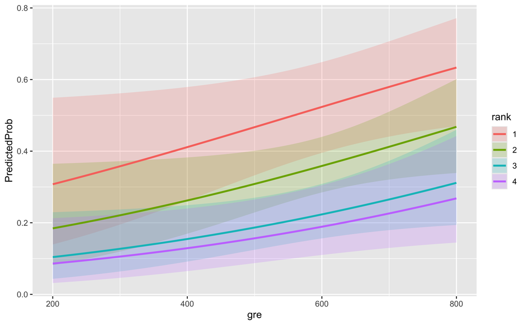

```r
library(ggplot2)
ggplot(newdata3, aes(x = gre, y = PredictedProb)) + geom_ribbon(aes(ymin = LL,
    ymax = UL, fill = rank), alpha = 0.2) + geom_line(aes(colour = rank),
    size = 1)
```

```r
library(margins)
#Stata=margins, dydx(*) para calculo dos efeitos marginais
mydata <- read.csv("https://stats.idre.ucla.edu/stat/data/binary.csv")
mylogit <- glm(admit ~ gre + gpa + rank, data = mydata, family = "binomial")
m <- margins(mylogit)
summary(m, type= "response")
```

|  | factor | AME | SE | z | p | lower | upper |
| --- | --- | --- | --- | --- | --- | --- | --- |
| 1 | gpa | 0.1517826001 | 0.0624263539 | 2.431387 | 1.504116e-02 | 2.942919e-02 | 0.2741360054 |
| 2 | gre | 0.0004481043 | 0.0002093275 | 2.140685 | 3.229944e-02 | 3.782991e-05 | 0.0008583788 |
| 3 | rank | -0.1093970872 | 0.0227246961 | -4.814018 | 1.479258e-06 | -1.539367e-01 | -0.0648575012 |

```r
m1 <- margins(mylogit, at=list(rank=3:4))
summary(m1, type= "response")
```

|  | factor | rank | AME | SE | z | p | lower | upper |
| --- | --- | --- | --- | --- | --- | --- | --- | --- |
| 1 | gpa | 3 | 0.1405501880 | 0.0585304817 | 2.401316 | 1.633622e-02 | 2.583255e-02 | 0.2552678241 |
| 2 | gpa | 4 | 0.1030841932 | 0.0455252813 | 2.264329 | 2.355392e-02 | 1.385628e-02 | 0.1923121049 |
| 3 | gre | 3 | 0.0004149431 | 0.0001966814 | 2.109722 | 3.488232e-02 | 2.945459e-05 | 0.0008004317 |
| 4 | gre | 4 | 0.0003043331 | 0.0001537123 | 1.979888 | 4.771614e-02 | 3.062539e-06 | 0.0006056037 |
| 5 | rank | 3 | -0.1013013422 | 0.0196886331 | -5.145169 | 2.672802e-07 | -1.398904e-01 | -0.0627123306 |
| 6 | rank | 4 | -0.0742977794 | 0.0085739747 | -8.665500 | 4.495349e-18 | -9.110246e-02 | -0.0574930978 |

```r
m2 <- margins(mylogit, at=list(rank=1:2, gpa=3))
summary(m2, type= "response")
```

|  | factor | rank | gpa | AME | SE | z | p | lower | upper |
| --- | --- | --- | --- | --- | --- | --- | --- | --- | --- |
| 1 | gpa | 1 | 3 | 0.1861062994 | 0.0758922977 | 2.452242 | 1.419690e-02 | 3.736013e-02 | 0.3348524695 |
| 2 | gpa | 2 | 3 | 0.1590191669 | 0.0592938689 | 2.681882 | 7.320925e-03 | 4.280532e-02 | 0.2752330144 |
| 3 | gre | 1 | 3 | 0.0005494374 | 0.0002562290 | 2.144322 | 3.200710e-02 | 4.723786e-05 | 0.0010516369 |
| 4 | gre | 2 | 3 | 0.0004694687 | 0.0002279264 | 2.059738 | 3.942356e-02 | 2.274122e-05 | 0.0009161961 |
| 5 | rank | 1 | 3 | -0.1341358457 | 0.0341318366 | -3.929933 | 8.496938e-05 | -2.010330e-01 | -0.0672386753 |
| 6 | rank | 2 | 3 | -0.1146128319 | 0.0287722073 | -3.983456 | 6.792015e-05 | -1.710053e-01 | -0.0582203418 |

## Exemplo Modelo Probit no R

```r
mydata <- read.csv("https://stats.idre.ucla.edu/stat/data/binary.csv")
mydata$rank <- factor(mydata$rank)

myprobit <- glm(admit ~ gre + gpa + rank, family = binomial(link = "probit"), data = mydata)

summary(myprobit)
```

```
Call:
glm(formula = admit ~ gre + gpa + rank, family = binomial(link = "probit"),
    data = mydata)

Coefficients:
             Estimate Std. Error z value Pr(>|z|)
(Intercept) -2.386836   0.673946  -3.542 0.000398 ***
gre          0.001376   0.000650   2.116 0.034329 *
gpa          0.477730   0.197197   2.423 0.015410 *
rank2       -0.415399   0.194977  -2.131 0.033130 *
rank3       -0.812138   0.208358  -3.898 9.71e-05 ***
rank4       -0.935899   0.245272  -3.816 0.000136 ***
---
Signif. codes:  0 '***' 0.001 '**' 0.01 '*' 0.05 '.' 0.1 ' ' 1

(Dispersion parameter for binomial family taken to be 1)

    Null deviance: 499.98  on 399  degrees of freedom
Residual deviance: 458.41  on 394  degrees of freedom
AIC: 470.41

Number of Fisher Scoring iterations: 4
```

```r
confint.default(myprobit)
```

```
                    2.5 %       97.5 %
(Intercept) -3.7077463656 -1.065926259
gre          0.0001015481  0.002649633
gpa          0.0912313065  0.864228789
rank2       -0.7975466475 -0.033252168
rank3       -1.2205115104 -0.403764641
rank4       -1.4166233054 -0.455175053
```

```r
# Previsao com dados novos
newdata1 <- data.frame(gre = 650, gpa = 4, rank = factor(1, levels = levels(mydata$rank)))

# Previsão com valores especificos
newdata1$prob <- predict(myprobit, newdata1, type = "response")
newdata1
```

| gre | gpa | rank | prob |
| --- | --- | --- | --- |
| 650 | 4 | 1 | 0.6621061 |

## Exemplo Modelo Logit no Python

```python
# Bibliotecas
import pandas as pd
import numpy as np
import matplotlib.pyplot as plt
import seaborn as sns
import statsmodels.formula.api as smf
import statsmodels.api as sm
from scipy.stats import norm

# Importação de dados
url = "https://stats.idre.ucla.edu/stat/data/binary.csv"
dados = pd.read_csv(url)

# Estatísticas Descritivas
print("\nEstatísticas Descritivas:")
```

```
Estatísticas Descritivas:
```

```python
print(dados.info())
```

```
<class 'pandas.core.frame.DataFrame'>
RangeIndex: 400 entries, 0 to 399
Data columns (total 4 columns):
 #   Column  Non-Null Count  Dtype
---  ------  --------------  -----
 0   admit   400 non-null    int64
 1   gre     400 non-null    int64
 2   gpa     400 non-null    float64
 3   rank    400 non-null    int64
dtypes: float64(1), int64(3)
memory usage: 12.6 KB
None
```

```python
print(dados.head())
```

```
   admit  gre   gpa  rank
0      0  380  3.61     3
1      1  660  3.67     3
2      1  800  4.00     1
3      1  640  3.19     4
4      0  520  2.93     4
```

```python
print(dados.describe())
```

```
            admit         gre         gpa       rank
count  400.000000  400.000000  400.000000  400.00000
mean     0.317500  587.700000    3.389900    2.48500
std      0.466087  115.516536    0.380567    0.94446
min      0.000000  220.000000    2.260000    1.00000
25%      0.000000  520.000000    3.130000    2.00000
50%      0.000000  580.000000    3.395000    2.00000
75%      1.000000  660.000000    3.670000    3.00000
max      1.000000  800.000000    4.000000    4.00000
```

```python
# Contagens de frequência para a variável categórica 'rank'
rank_counts = dados['rank'].value_counts()
print("\nContagens de frequência para 'rank':")
```

```
Contagens de frequência para 'rank':
```

```python
print(rank_counts)
```

```
rank
2    151
3    121
4     67
1     61
Name: count, dtype: int64
```

```python
# Proporçoes para a variável categórica 'rank'
rank_proportions = dados['rank'].value_counts(normalize=True)
print("\nProporções para 'rank':")
```

```
Proporções para 'rank':
```

```python
print(rank_proportions)
```

```
rank
2    0.3775
3    0.3025
4    0.1675
1    0.1525
Name: proportion, dtype: float64
```

```python
# Tabulação cruzada entre 'rank' e 'admit'
rank_admit_crosstab = pd.crosstab(dados['rank'], dados['admit'])
print("\nTabulação cruzada entre 'rank' e 'admit':")
```

```
Tabulação cruzada entre 'rank' e 'admit':
```

```python
print(rank_admit_crosstab)
```

```
admit   0   1
rank
1      28  33
2      97  54
3      93  28
4      55  12
```

```python
# Estimação do Modelo
modelo_logit = smf.logit('admit ~ gre + gpa + C(rank)', data=dados)
result = modelo_logit.fit()
```

```
Optimization terminated successfully.
         Current function value: 0.573147
         Iterations 6
```

```python
print("\nResultado do Modelo Logit")
```

```
Resultado do Modelo Logit
```

```python
print(result.summary())
```

```
                           Logit Regression Results
==============================================================================
Dep. Variable:                  admit   No. Observations:                  400
Model:                          Logit   Df Residuals:                      394
Method:                           MLE   Df Model:                            5
Date:                Seg, 27 Out 2025   Pseudo R-squ.:                 0.08292
Time:                        17:08:13   Log-Likelihood:                -229.26
converged:                       True   LL-Null:                       -249.99
Covariance Type:            nonrobust   LLR p-value:                 7.578e-08
================================================================================
                   coef    std err          z      P>|z|      [0.025      0.975]
--------------------------------------------------------------------------------
Intercept       -3.9900      1.140     -3.500      0.000      -6.224      -1.756
C(rank)[T.2]    -0.6754      0.316     -2.134      0.033      -1.296      -0.055
C(rank)[T.3]    -1.3402      0.345     -3.881      0.000      -2.017      -0.663
C(rank)[T.4]    -1.5515      0.418     -3.713      0.000      -2.370      -0.733
gre              0.0023      0.001      2.070      0.038       0.000       0.004
gpa              0.8040      0.332      2.423      0.015       0.154       1.454
================================================================================
```

```python
# Calcula as razoes de chance (odds ratios)
odds_ratios = np.exp(result.params)
print("\nOdds Ratios:")
```

```
Odds Ratios:
```

```python
print(odds_ratios)
```

```
Intercept       0.018500
C(rank)[T.2]    0.508931
C(rank)[T.3]    0.261792
C(rank)[T.4]    0.211938
gre             1.002267
gpa             2.234545
dtype: float64
```

```python
# Calculando os efeitos marginais na média dos preditores
margeff_mean = result.get_margeff(at='mean')
print("\nEfeitos Marginais com a média:")
```

```
Efeitos Marginais com a média:
```

```python
print(margeff_mean.summary())
```

```
        Logit Marginal Effects
=====================================
Dep. Variable:                  admit
Method:                          dydx
At:                              mean
================================================================================
                  dy/dx    std err          z      P>|z|      [0.025      0.975]
--------------------------------------------------------------------------------
C(rank)[T.2]    -0.1415      0.067     -2.126      0.033      -0.272      -0.011
C(rank)[T.3]    -0.2807      0.072     -3.890      0.000      -0.422      -0.139
C(rank)[T.4]    -0.3250      0.087     -3.742      0.000      -0.495      -0.155
gre              0.0005      0.000      2.079      0.038    2.71e-05       0.001
gpa              0.1684      0.069      2.436      0.015       0.033       0.304
================================================================================
```

```python
# Calculando as os efeitos marginais e as probabilidades previstas em valores específicos
specific_values = pd.DataFrame({
    'gre': [600] * 4,
    'gpa': [3.5] * 4,
    'rank': [1, 2, 3, 4]
})

# Calculando as probabilidades previstas
#params = result.params
predictions = result.predict(specific_values)
specific_values['Probabilidades'] = predictions

# Obtendo os nomes dos coeficientes
coef_names = result.params.index

# Calculando os efeitos marginais manualmente
marginal_effects = {}

# Efeitos marginais para variáveis contínuas
for var in ['gre', 'gpa']:
    marginal_effects[var] = result.params[var] * predictions * (1 - predictions)

# Efeitos marginais para variáveis categóricas
for rank in [2, 3, 4]:  # Nota: Rank 1 é a categoria de referência e não está incluída nos coeficientes
    coef_name = f'C(rank)[T.{rank}]'
    if coef_name in result.params:
        marginal_effects[f'rank_{rank}'] = result.params[coef_name] * predictions * (1 - predictions)
    else:
        print(f"Coeficiente '{coef_name}' não encontrado na saída do modelo.")

# Convertendo para DataFrame para visualização
marginal_effects_df = pd.DataFrame(marginal_effects, index=[1, 2, 3, 4])
print("\nEfeitos Marginais em Valores Específicos:")
```

```
Efeitos Marginais em Valores Específicos:
```

```python
print(marginal_effects_df)
```

```
        gre       gpa    rank_2    rank_3    rank_4
1  0.000533  0.189291 -0.159016 -0.315517 -0.365253
2  0.000412  0.146297 -0.122898 -0.243853 -0.282293
3  0.000366  0.130008 -0.109215 -0.216703 -0.250863
4       NaN       NaN       NaN       NaN       NaN
```

```python
print("\nProbabilidades previstas em valores específicos:")
```

```
Probabilidades previstas em valores específicos:
```

```python
print(specific_values)
```

```
   gre  gpa  rank  Probabilidades
0  600  3.5     1        0.545575
1  600  3.5     2        0.379273
2  600  3.5     3        0.239141
3  600  3.5     4        0.202837
```

```python
print("\nGráfico das Probabilidades previstas")
```

```
Gráfico das Probabilidades previstas
```

```python
# Define a range of GRE values
gre_values = np.linspace(200, 800, 100)  # GRE values from 200 to 800
gpa_value = 3.5  # Constant GPA value
ranks = [1, 2, 3, 4]  # Different ranks

# Cria uma DataFrame para armazenar probabilidades previstas
predicted_probs = pd.DataFrame()

for rank in ranks:
    specific_values = pd.DataFrame({
        'gre': gre_values,
        'gpa': gpa_value,
        'rank': rank
    })
    predictions = result.predict(specific_values)
    predicted_probs[f'Rank {rank}'] = predictions

# Plota as probabilidades previstas
plt.figure(figsize=(10, 6))
for rank in ranks:
    plt.plot(gre_values, predicted_probs[f'Rank {rank}'], label=f'Rank {rank}')

plt.xlabel('GRE')
plt.ylabel('Probabilidade de Admissão')
plt.title('Probabilidade de Admissão por escore de GRE e Rank')
plt.legend(title='Rank')
plt.grid(False)
plt.ylim(0, 1)
```

```
(0.0, 1.0)
```

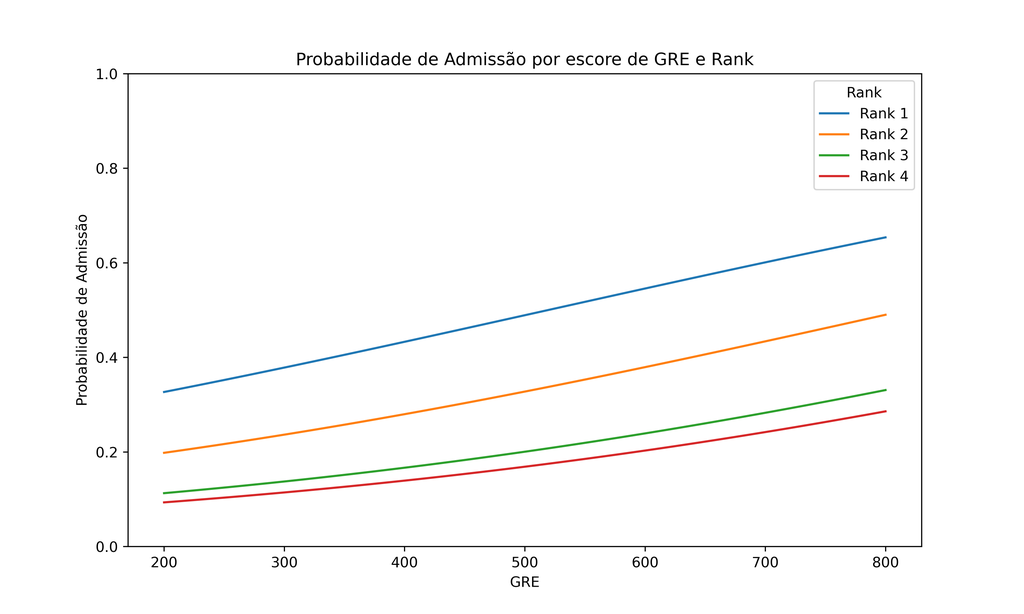

```python
# Mostra o plot
plt.show()
```

**Interpretação das razões de chance da variável categórica:**

1. **Rank 2 (0,508931):** As chances de ser admitido para alguém no rank 2 são aproximadamente 50,9% das chances de ser admitido para alguém no rank 1. Em outras palavras, as chances de admissão para o rank 2 são cerca de 49,1% menores em comparação com classificação 1, mantendo outras variáveis constantes.
2. **Rank 3 (0,261792):** As chances de ser admitido para alguém no rank 3 são de aproximadamente 26,2% das chances de ser admitido para alguém no rank 1. Assim, as chances de admissão para rank 3 são cerca de 73,8% menores em comparação com rank 1 , mantendo outras variáveis constantes.
3. **Rank 4 (0,211938):** As chances de ser admitido para alguém no rank 4 são aproximadamente 21,2% das chances de ser admitido para alguém no rank 1. Portanto, as chances de admissão para a rank 4 são cerca de 78,8% menores em comparação com rank 1, mantendo outras variáveis constantes.

**Interpretação de efeitos marginais**

**Efeito Marginal para Variáveis Categóricas (rank):**

Quanto mais negativo for o efeito marginal, maior será a redução da probabilidade de admissão para determinado posto face ao posto de referência.

**Probabilidades com valores específicos por Rank:**

1. **Rank 1:** A probabilidade de ser admitido é aproximadamente 0,546 ou 54,6% para alguém com pontuação gre de 600 e gpa de 3,5.
2. **Rank 2:** A probabilidade de ser admitido diminui para aproximadamente 0,379 ou37,9% para o mesmo gre e gpa, mas com rank 2.
3. **Rank 3:** A probabilidade de ser admitido diminui ainda mais para aproximadamente 0,239 ou 23,9% para rank 3.
4. **Rank 4:** A probabilidade de ser admitido é a mais baixa, aproximadamente 0,203 ou 20,3 % para rank 4.

## Exemplo Modelo Probit no Python

```python
import pandas as pd
import statsmodels.api as sm
import statsmodels.formula.api as smf

#from statsmodels.discrete.discrete_model import Probit

# Importação de dados
url = "https://stats.idre.ucla.edu/stat/data/binary.csv"
dados = pd.read_csv(url)

# Estimação do Modelo Probit
probit = smf.probit('admit ~ gre + gpa + C(rank)', data=dados)
probit_result = probit.fit()
```

```
Optimization terminated successfully.
         Current function value: 0.573016
         Iterations 5
```

```python
# Print the summary of the Probit model
print(probit_result.summary())
```

```
                          Probit Regression Results
==============================================================================
Dep. Variable:                  admit   No. Observations:                  400
Model:                         Probit   Df Residuals:                      394
Method:                           MLE   Df Model:                            5
Date:                Seg, 27 Out 2025   Pseudo R-squ.:                 0.08313
Time:                        17:08:22   Log-Likelihood:                -229.21
converged:                       True   LL-Null:                       -249.99
Covariance Type:            nonrobust   LLR p-value:                 7.219e-08
================================================================================
                   coef    std err          z      P>|z|      [0.025      0.975]
--------------------------------------------------------------------------------
Intercept       -2.3868      0.674     -3.541      0.000      -3.708      -1.066
C(rank)[T.2]    -0.4154      0.195     -2.126      0.033      -0.798      -0.032
C(rank)[T.3]    -0.8121      0.209     -3.893      0.000      -1.221      -0.403
C(rank)[T.4]    -0.9359      0.246     -3.810      0.000      -1.417      -0.454
gre              0.0014      0.001      2.120      0.034       0.000       0.003
gpa              0.4777      0.195      2.444      0.015       0.095       0.861
================================================================================
```

```python
# Calculando as probabilidades previstas em valores específicos
specific_values = pd.DataFrame({
    'gre': [650],
    'gpa': [4.0],
    'rank': [1]
})

# Ajusta a variável 'rank' para ser categórica com os mesmos níveis dos dados originais
specific_values['rank'] = pd.Categorical(specific_values['rank'], categories=[1, 2, 3, 4])


# Prevê a probabilidade de admit para os valores específicos
specific_values['pred_prob'] = probit_result.predict(specific_values)
print("\nPredicted Probability at Specific Values:")
```

```
Predicted Probability at Specific Values:
```

```python
print(specific_values)
```

```
   gre  gpa rank  pred_prob
0  650  4.0    1   0.662106
```